# Bank Marketing Campaign Analysis

Feiran Zhang

2025-04-18

# Introduction

**Analysis Objectives**: 1. Explore subscription rates by job type 2. Visualize age distribution differences between subscribers and non-subscribers 3. Identify key demographic factors associated with term deposit subscriptions

# Descriptive Analysis

## Subscription Rates by Job Type

Term Deposit Subscription Rates by Occupation

| Job Category | Subscription | Count | Percentage (%) |
| --- | --- | --- | --- |
| blue-collar | no | 9024 | 20.0 |
| management | no | 8157 | 18.0 |
| technician | no | 6757 | 14.9 |
| admin. | no | 4540 | 10.0 |
| services | no | 3785 | 8.4 |
| retired | no | 1748 | 3.9 |
| self-employed | no | 1392 | 3.1 |
| entrepreneur | no | 1364 | 3.0 |
| management | yes | 1301 | 2.9 |
| housemaid | no | 1131 | 2.5 |
| unemployed | no | 1101 | 2.4 |
| technician | yes | 840 | 1.9 |
| blue-collar | yes | 708 | 1.6 |
| student | no | 669 | 1.5 |
| admin. | yes | 631 | 1.4 |
| retired | yes | 516 | 1.1 |
| services | yes | 369 | 0.8 |
| student | yes | 269 | 0.6 |
| unknown | no | 254 | 0.6 |
| self-employed | yes | 187 | 0.4 |
| unemployed | yes | 202 | 0.4 |
| entrepreneur | yes | 123 | 0.3 |
| housemaid | yes | 109 | 0.2 |
| unknown | yes | 34 | 0.1 |

Note:  
Data collected from a bank marketing campaign dataset

### Table Description:

This table presents the distribution of term deposit subscriptions across different job categories. Blue-collar workers represent the largest group contacted (9,024 cases) but show a relatively low subscription rate. Management professionals have a relatively higher subscription count (1,301 cases). Students, despite having a smaller absolute count, exhibit the highest relative subscription rate, indicating a stronger interest in term deposits compared to other occupations. Retirees also have a notable subscription rate, potentially due to their financial planning needs.

# Graphical Analysis

## Age Distribution by Subscription Status

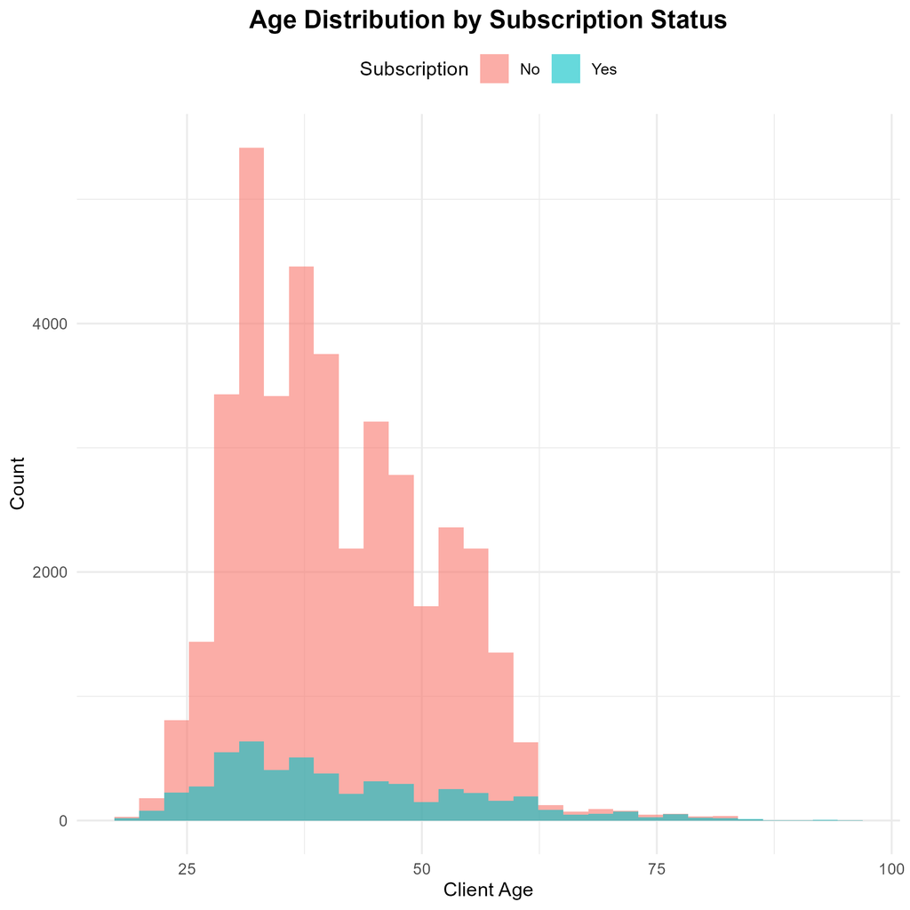

### Figure Description:

The histogram illustrates the age distribution of clients who were contacted during the campaign, categorized by subscription status. The majority of non-subscribers (shown in red) are in the 25-45 age range, while a significant portion of subscribers (shown in blue) are observed in the 25-35 and 55-65 age groups. This suggests that younger professionals and pre-retirees may be more likely to subscribe to term deposits. The overall distribution is skewed towards younger clients, but the relative proportion of subscriptions increases for older age brackets.